# Lab_11

Author

Matheus Soares - RA:277210

### Pacotes

```python
from plotnine import (ggplot, aes, geom_point, geom_smooth, facet_wrap,
                      facet_grid, scale_x_log10, scale_y_log10, labs,
                      theme_bw, theme)
```

### 1. Importando o conjunto de dados

```python
from plotnine.data import diamonds
diamonds.head()
```

|  | carat | cut | color | clarity | depth | table | price | x | y | z |
| --- | --- | --- | --- | --- | --- | --- | --- | --- | --- | --- |
| 0 | 0.23 | Ideal | E | SI2 | 61.5 | 55.0 | 326 | 3.95 | 3.98 | 2.43 |
| 1 | 0.21 | Premium | E | SI1 | 59.8 | 61.0 | 326 | 3.89 | 3.84 | 2.31 |
| 2 | 0.23 | Good | E | VS1 | 56.9 | 65.0 | 327 | 4.05 | 4.07 | 2.31 |
| 3 | 0.29 | Premium | I | VS2 | 62.4 | 58.0 | 334 | 4.20 | 4.23 | 2.63 |
| 4 | 0.31 | Good | J | SI2 | 63.3 | 58.0 | 335 | 4.34 | 4.35 | 2.75 |

### 2. Associação entre peso (carat) e preço (price)

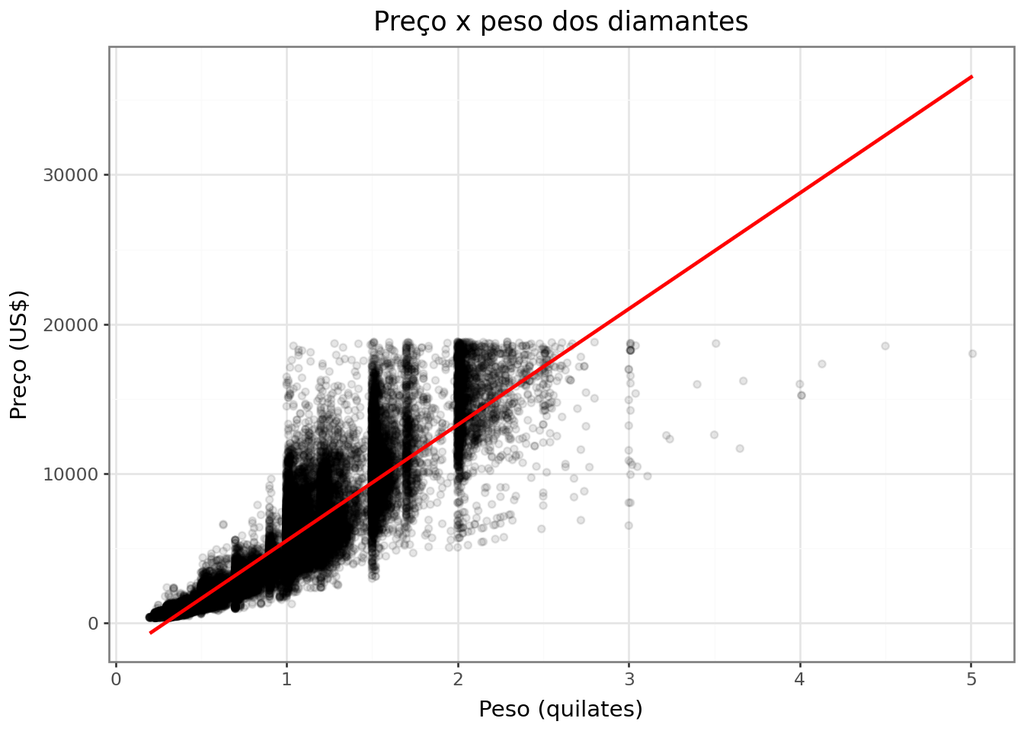

```python
(
    ggplot(diamonds, aes(x="carat", y="price"))
    + geom_point(alpha=0.1)
    + geom_smooth(method="lm", color="red")
    + labs(x="Peso (quilates)", y="Preço (US$)",
           title="Preço x peso dos diamantes")
    + theme_bw()
)
```

Como são quase 54 mil diamantes, os pontos ficam muito sobrepostos, então usei `alpha` baixo pra ver onde estão concentrados. Também coloquei títulos nos eixos e uma linha de tendência. Pelo gráfico, quanto maior o peso, maior o preço, mas a relação não é uma reta: o preço sobe cada vez mais rápido e a variação do preço também aumenta nos diamantes mais pesados. Para deixar a relação mais fácil de ler, testei a escala logarítmica nos dois eixos:

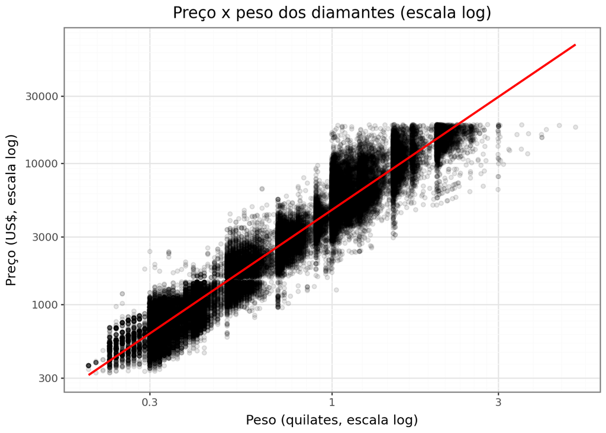

```python
(
    ggplot(diamonds, aes(x="carat", y="price"))
    + geom_point(alpha=0.1)
    + geom_smooth(method="lm", color="red")
    + scale_x_log10()
    + scale_y_log10()
    + labs(x="Peso (quilates, escala log)", y="Preço (US$, escala log)",
           title="Preço x peso dos diamantes (escala log)")
    + theme_bw()
)
```

Na escala log a relação fica bem próxima de uma reta, e a dispersão fica parecida ao longo do peso. Ou seja, o preço aumenta de forma positiva e forte com o peso.

### 3. A relação é a mesma para os diferentes cortes?

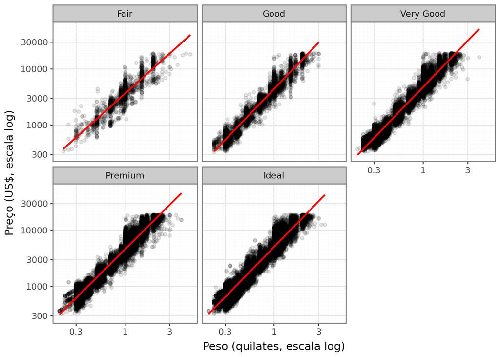

```python
(
    ggplot(diamonds, aes(x="carat", y="price"))
    + geom_point(alpha=0.1)
    + geom_smooth(method="lm", color="red")
    + facet_wrap("cut")
    + scale_x_log10()
    + scale_y_log10()
    + labs(x="Peso (quilates, escala log)", y="Preço (US$, escala log)")
    + theme_bw()
)
```

Em todos os cortes a relação é positiva e parecida: diamantes mais pesados são mais caros. O que muda é o nível e um pouco a inclinação da reta entre os cortes, então a tendência geral é a mesma, mas o preço para um mesmo peso não é exatamente igual em cada tipo de corte.

### 4. Preço e peso por corte, cor e clareza

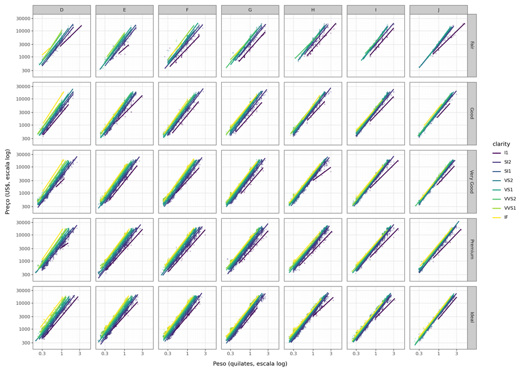

```python
(
    ggplot(diamonds, aes(x="carat", y="price", color="clarity"))
    + geom_point(alpha=0.2, size=0.5)
    + geom_smooth(method="lm", se=False)
    + facet_grid("cut ~ color")
    + scale_x_log10()
    + scale_y_log10()
    + labs(x="Peso (quilates, escala log)", y="Preço (US$, escala log)")
    + theme_bw()
    + theme(figure_size=(14, 10))
)
```

A principal dificuldade foi a quantidade de combinações: são 5 cortes, 7 cores e 8 níveis de clareza, o que dá 280 grupos. Para caber no gráfico, usei painéis para corte e cor e deixei a clareza como cor dos pontos, mas o resultado fica poluído. Algumas combinações também têm poucos diamantes (por exemplo, clareza I1 ou IF em certas cores), e aí as retas ficam pouco confiáveis. Mesmo assim, em quase todos os painéis a relação entre preço e peso continua positiva. O que muda de uma configuração pra outra é o nível dos preços (clareza e cor melhores tendem a ficar acima) e, em alguns casos, a inclinação, então a relação não é exatamente a mesma, apesar de o sentido ser sempre o mesmo.